[figure not shown]

#### Prepared by: Kyle Gatt

### Total Run Projections

Stock-specific inriver run timing models spanning years 2000 to 2023 were evaluated to project the total run of sockeye salmon to the Kenai and Kasilof Rivers. Projection model performance was assessed using the mean arctangent absolute percent error (MAAPE) between the projected daily total run estimates and actual runs up to the date the projection was run. The top three models with the lowest MAAPE were selected for each stock and a weighted hybrid model approach was applied. Model weighted were assigned based on the running MAAPE of each selected model, with a lower MAAPE receiving a greater weight towards the final projection estimate.

**Table 1.-** Management tiers for the late-run stock Kenai River sockeye salmon.

| Tier | Total Run Size |
| --- | --- |
| Lower | Less than 2,300,000 |
| Middle | 2,300,000 to 4,600,000 |
| Upper | Greater than 4,600,000 |

**Table 2.-** Total run projections by stock.

| Stock | Year | Timing | MAAPE | Model projection | Model weight | Weighted projection | Total |  |
| --- | --- | --- | --- | --- | --- | --- | --- | --- |
| Kasilof | 2023 | 77.6% | 12.83 | 2,234,122 | 0.37 | 816,502.7 | 2,090,836 |  |
|  | 2019 | 86.3% | 13.07 | 2,008,394 | 0.36 | 720,181.3 |  |  |
|  | 2009 | 86.3% | 16.99 | 2,008,197 | 0.28 | 554,152.4 |  |  |
| Kenai | 2022 | 78.9% | 20.55 | 4,440,799 | 0.33 | 1,487,561.8 |  | 4,351,476 |
|  | 2010 | 77.7% | 20.60 | 4,509,270 | 0.33 | 1,506,581.1 |  |  |
|  | 2009 | 85.4% | 20.80 | 4,101,740 | 0.33 | 1,357,332.6 |  |  |

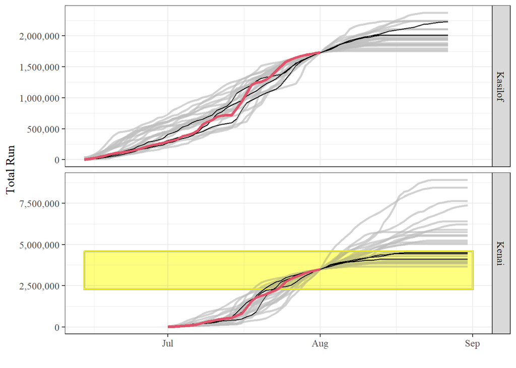

**Figure 1.-** The top three competing models for each stock (black lines) relative to actual daily cumulative total runs (red line). All other competing models are indicated in grey. The middle management tier (2.3 to 4.6 million fish) for late-run stock Kenai River sockeye salmon is indicated in yellow.

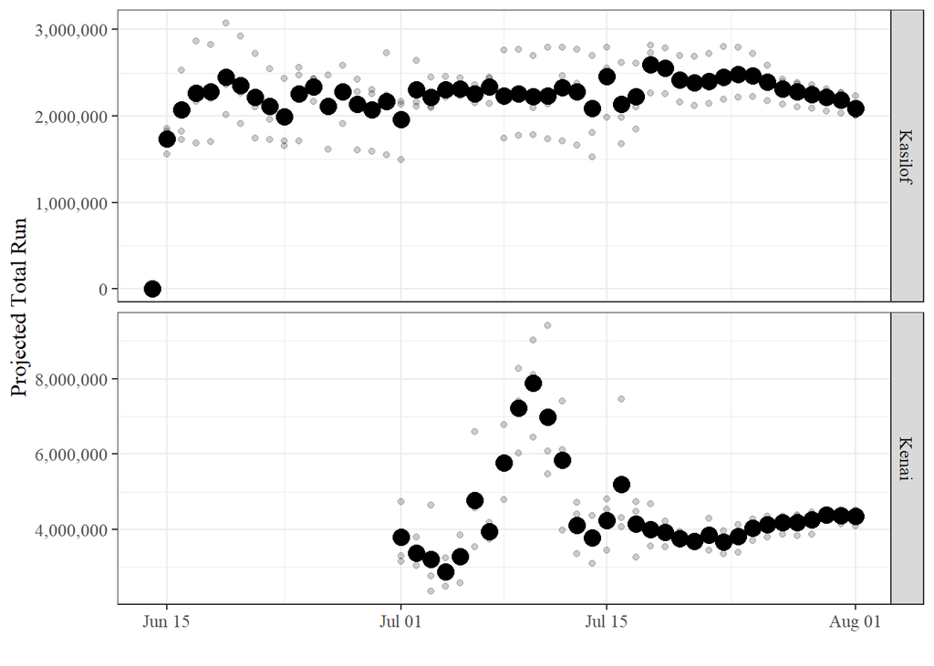

**Figure 2.-** Weighted total run estimates (black dots) using the top three selected run timing models by projection date and stock. Grey dots represent individual total run projections for each selected model by date.

### Age Allocation Modeling

A weighted age composition method was used to estimate the contributions of Kenai, Kasilof, Susitna, and Crescent rivers, Fish Creek, and“Other” sockeye salmon stocks to commercial fishery harvests in UCI (see Bernard 1983 and Tobias and Tarbox 1999 for general methods). The method is based on the assumption that specific fisheries exploit each stock equally. The relative contribution of a specific age class in the escapement represents the relative contribution of that age class in the commercial harvest in a specific time and area fished. Sockeye salmon harvests in the various fishery subdistricts were allocated to the stocks entering major rivers that were in closest proximity to the fishery.

**Table 3.-** Cumulative total run estimates to date for primary Upper Cook Inlet sockeye salmon stocks.

| Stock | Run component | Total |
| --- | --- | --- |
| Crescent | Commercial Harvest | 4,529 |
|  | Escapement | 44,388 |
|  | Subtotal | 48,917 |
| Fish Creek | Commercial Harvest | 8,759 |
|  | Escapement | 34,227 |
|  | Subtotal | 42,986 |
| Kasilof | Commercial Harvest | 431,920 |
|  | Escapement | 991,499 |
|  | Personal Use and Sport | 309,296 |
|  | Subtotal | 1,732,715 |
| Kenai | Commercial Harvest | 998,314 |
|  | Escapement | 1,744,454 |
|  | Personal Use and Sport | 761,612 |
|  | Subtotal | 3,504,380 |
| Other | Commercial Harvest | 215,648 |
|  | Escapement | 445,002 |
|  | Subtotal | 660,650 |
| Susitna | Commercial Harvest | 65,725 |
|  | Escapement | 152,114 |
|  | Subtotal | 217,839 |

**Table 4.-** Age composition of returns to the Kenai and Kasilof Rivers in 2024 relative to preseason forecasts.

| Stock | Age class | Composition of return | Run to date | Forecasted run | Percent remaining | Total fish remaining |
| --- | --- | --- | --- | --- | --- | --- |
| Kasilof | 0.2 | 0.0% | 5,166 | 0 | -Inf% | 0 |
|  | 0.3 | 0.0% | 0 | 0 | 0.0% | 0 |
|  | 0.4 | 0.0% | 0 | 0 | 0.0% | 0 |
|  | 1.1 | 1.0% | 9,106 | 0 | -Inf% | 0 |
|  | 1.2 | 42.0% | 719,597 | 506,000 | -42.0% | 0 |
|  | 1.3 | 47.0% | 806,750 | 332,218 | -143.0% | 0 |
|  | 1.4 | 0.0% | 2,227 | 0 | -Inf% | 0 |
|  | 2.1 | 1.0% | 9,191 | 0 | -Inf% | 0 |
|  | 2.2 | 9.0% | 164,137 | 221,924 | 26.0% | 57,787 |
|  | 2.3 | 1.0% | 16,542 | 55,019 | 70.0% | 38,477 |
|  | 2.4 | 0.0% | 0 | 0 | 0.0% | 0 |
| Kenai | 0.2 | 0.0% | 0 | 0 | 0.0% | 0 |
|  | 0.3 | 0.0% | 0 | 0 | 0.0% | 0 |
|  | 0.4 | 0.0% | 0 | 0 | 0.0% | 0 |
|  | 1.1 | 0.0% | 2,506 | 0 | -Inf% | 0 |
|  | 1.2 | 27.0% | 938,176 | 515,248 | -82.0% | 0 |
|  | 1.3 | 62.0% | 2,166,992 | 2,143,928 | -1.0% | 0 |
|  | 1.4 | 1.0% | 38,612 | 0 | -Inf% | 0 |
|  | 2.1 | 0.0% | 0 | 0 | 0.0% | 0 |
|  | 2.2 | 7.0% | 241,240 | 248,800 | 3.0% | 7,560 |
|  | 2.3 | 3.0% | 116,853 | 472,484 | 75.0% | 355,631 |
|  | 2.4 | 0.0% | 0 | 0 | 0.0% | 0 |

### Inseason Total Run Tracking

**Table 5.-** Cumulative harvest and passage estimates of sockeye salmon in Upper Cook Inlet (UCI), 2024. All personal use and sport harvest estimates are projections based on recent five-year average harvest rates within each fishery. The Susitna River escapement estimate uses the average harvest rate of this stock in UCI commercial salmon fisheries (42%; 2007 to 2015), the average run timing, and pre-season forecasts. The Crescent River escapement estimate is based on the average commercial sockeye salmon harvest in the western district and average harvest rate of this stock (46.3%) from 2006 to 2021.

| Run component | Fishery | Cumulative season total |
| --- | --- | --- |
| Commercial Harvest | Central District Drift - State Waters | 1,324,220 |
|  | Kasilof Section Set Net Fishery | 1,189 |
|  | Kenai Section Set Net Fishery | 24,785 |
|  | Northern District Set Net Fishery - Eastern Subdistrict | 21,368 |
|  | Northern District Set Net Fishery - General Subdistrict | 15,449 |
|  | UCI EEZ | 316,296 |
|  | Western Subdistrict Set Net Fishery | 84,380 |
|  | Subtotal | 1,787,687 |
| Escapement | Crescent Escapement | 44,388 |
|  | Fish Creek Escapement | 34,227 |
|  | Kasilof River Escapement | 991,499 |
|  | Kenai River Escapement | 1,744,454 |
|  | Susitna Escapement | 152,114 |
|  | Other | 445,002 |
|  | Subtotal | 3,411,684 |
| Personal Use and Sport | Kasilof Personal Use Dipnet | 203,060 |
|  | Kasilof Personal Use Gillnet | 35,266 |
|  | Kasilof Sport | 70,970 |
|  | Kenai Personal Use Dipnet | 506,970 |
|  | Kenai Sport | 254,641 |
|  | Subtotal | 1,070,907 |
| Grand Total |  | 6,270,278 |